# ANOVA part I

Ane Kleiven

2025-02-26

# 1 Ex-1: Chlorine levels in cities

```r
library(BIAS.data)
library(car)

city.tbl <- BIAS.data::city

# stack the data and create a response column y
city.stacked <- stack(city.tbl)
# change column names
colnames(city.stacked) <- c("y", "city")
```

**Assume an ANOVA-model with chlorine as response and city as a factor. What assumptions do you make?**

There is a linear relationship between the response variable and the factor levels. The residuals are independent and normally distributed with constant variance. mu i is the expected chlorine level in city i.

The model: yij = mu i + eij where eij ~ N(0, sigma^2)

**Make a box-plot of the data using the Boxplot-function in the ‘car’-package Describe the variabilities between cities and within cities.**

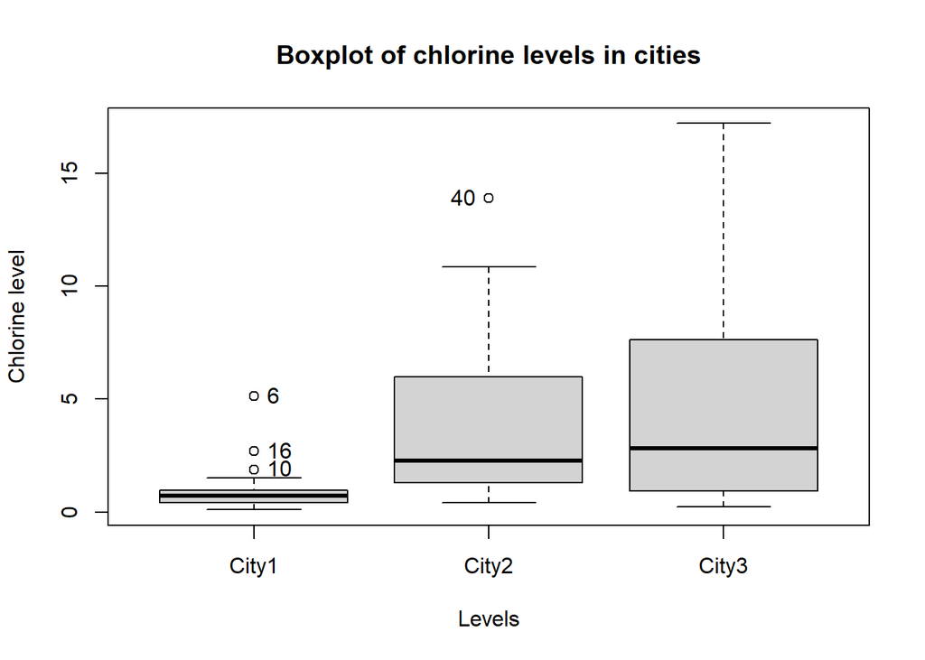

```
## [1] "6"  "10" "16" "40"
```

```r
car::Boxplot(city.stacked$y ~ city.stacked$city, xlab = 'Levels', ylab = 'Chlorine level', main = 'Boxplot of chlorine levels in cities')
```

We can see that the chlorines levels varies between the three cities. In city 1, the mean chlorine level is very low, with a lower variance than seen in city 2 and city 3. City 2 and city 3 looks more similar, with a higher mean chlorine level than city 1. The variance in city 3 is higher than in city 2.

**Fit the model (using sum to zero parametrization) and perform a residual analysis. Comment on the model fit.**

```r
options(contrasts = c("contr.sum", "contr.poly"))
model.city <- lm(formula = y~city, data = city.stacked)
summary(model.city, cor = FALSE)
```

```
##
## Call:
## lm(formula = y ~ city, data = city.stacked)
##
## Residuals:
##    Min     1Q Median     3Q    Max
## -4.444 -2.438 -0.617  0.553 12.516
##
## Coefficients:
##             Estimate Std. Error t value Pr(>|t|)
## (Intercept)   3.2608     0.4741   6.878 5.07e-09 ***
## city1        -2.2088     0.6704  -3.295   0.0017 **
## city2         0.7857     0.6704   1.172   0.2461
## ---
## Signif. codes:  0 '***' 0.001 '**' 0.01 '*' 0.05 '.' 0.1 ' ' 1
##
## Residual standard error: 3.672 on 57 degrees of freedom
## Multiple R-squared:  0.1637, Adjusted R-squared:  0.1343
## F-statistic: 5.578 on 2 and 57 DF,  p-value: 0.006132
```

```r
car::Anova(model.city)
```

```
## Anova Table (Type II tests)
##
## Response: y
##           Sum Sq Df F value   Pr(>F)
## city      150.43  2  5.5779 0.006132 **
## Residuals 768.62 57
## ---
## Signif. codes:  0 '***' 0.001 '**' 0.01 '*' 0.05 '.' 0.1 ' ' 1
```

```r
anova(model.city)
```

```
## Analysis of Variance Table
##
## Response: y
##           Df Sum Sq Mean Sq F value   Pr(>F)
## city       2 150.43  75.216  5.5779 0.006132 **
## Residuals 57 768.62  13.485
## ---
## Signif. codes:  0 '***' 0.001 '**' 0.01 '*' 0.05 '.' 0.1 ' ' 1
```

#### Redidual analysis

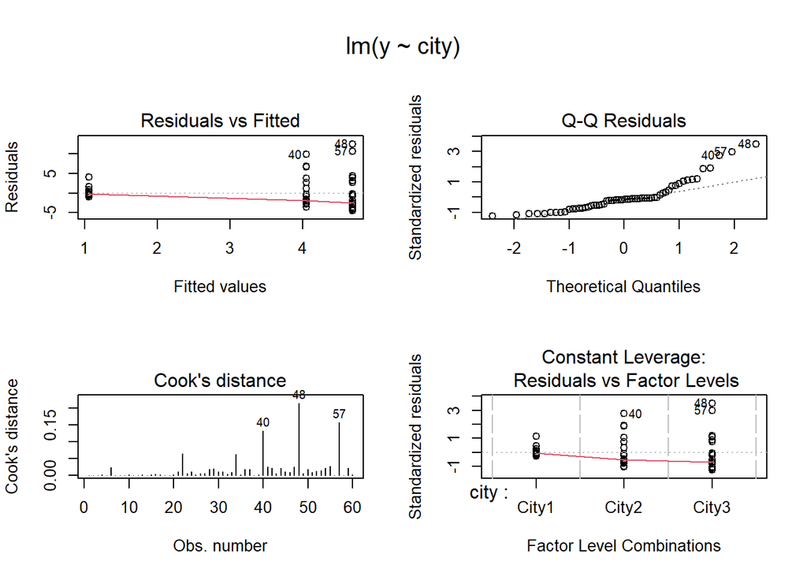

```r
par(oma=c(0,0,3,0), mfrow=c(2,2))
plot(model.city, which = c(1,2,4,5), add.smooth=TRUE)
```

The residual analysis reveals a two problems: 1. Non constant variance - also observed in the boxplots. 2. A skewed and non normal distribution of the residuals, with a heavy tail to the right.

The R squared is quite small, only 0.16, so there is a lot of unexplained variance in the response variable. The hypothesis test of effect of the group variable city appears to be highlt significant, but we should be careful concluding until we have tried to improve the fit of the model.

**Make a log-transformation of y to create the variable ylog**

```r
library(tidyverse)

logy <- log(city.stacked$y)
city.stacked <- mutate(city.stacked, ylog = logy)
```

**Fit a new model with log y as response and check the model fit again.**

```r
options(contrasts = c('contr.sum', 'contr.poly'))
logmodel.city <- lm(formula = ylog ~ city, data = city.stacked)
summary(logmodel.city)
```

```
##
## Call:
## lm(formula = ylog ~ city, data = city.stacked)
##
## Residuals:
##      Min       1Q   Median       3Q      Max
## -2.39867 -0.59544 -0.01755  0.71218  1.93257
##
## Coefficients:
##             Estimate Std. Error t value Pr(>|t|)
## (Intercept)   0.5342     0.1332   4.009 0.000179 ***
## city1        -0.8317     0.1884  -4.414 4.58e-05 ***
## city2         0.3944     0.1884   2.093 0.040818 *
## ---
## Signif. codes:  0 '***' 0.001 '**' 0.01 '*' 0.05 '.' 0.1 ' ' 1
##
## Residual standard error: 1.032 on 57 degrees of freedom
## Multiple R-squared:  0.2549, Adjusted R-squared:  0.2287
## F-statistic: 9.748 on 2 and 57 DF,  p-value: 0.0002283
```

```r
car::Anova(logmodel.city)
```

```
## Anova Table (Type II tests)
##
## Response: ylog
##           Sum Sq Df F value    Pr(>F)
## city      20.771  2  9.7484 0.0002283 ***
## Residuals 60.724 57
## ---
## Signif. codes:  0 '***' 0.001 '**' 0.01 '*' 0.05 '.' 0.1 ' ' 1
```

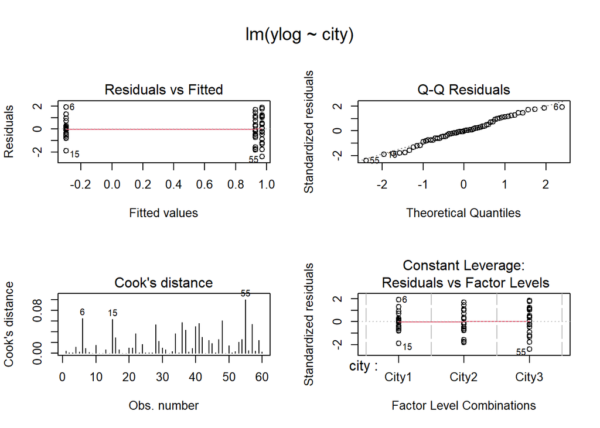

```r
par(oma=c(0,0,3,0), mfrow=c(2,2))
plot(logmodel.city, which = c(1,2,4,5), add.smooth=TRUE)
```

In the log model, we can see that the residuals are more normally distributed and the assumption of constant variance is met. The R squared is 0.25, meaning that the model explains more of the variance in the response variable than the previous model.

**Estimate all model parameters for the latter model. Explain what the parameters measure given the parametrization used.**

```r
coefs <- logmodel.city$coefficients
coefs
```

```
## (Intercept)       city1       city2
##   0.5342466  -0.8317074   0.3943982
```

```r
# mu (on the log scale)
mu_estimate = coefs[1]
mu_1 = mu_estimate + coefs[2]
mu_2 = mu_estimate + coefs[3]

# coefs for city 3: coefs2 + coefs3 + coefs4 = 0
# coefs 3 = - coefs2 - coefs3

coefs_city3 <- - coefs[2] - coefs[3]
mu_3 = mu_estimate + coefs_city3

# The estimate of the error variance
# sigma^2 = MSE = SSE/(N-3)
# ssE = residuals in the ANOVA table
sigma2 = 60.724 / (60-3)
```

Sigma squared is the variance for log-chlorine levels measured in the same city (within city variance).

Between city variance is the variance of the city means.

**State the hypotheses for testing whether the expected chlorine levels differ between the cities, choose a test level α and perform the test. What is the conclusion?**

Test level alpha = 0.05

H0: mu_1 = mu_2 = mu_3 H1: At least one of the means are different. Some mu_i is not equal to the others.

```r
anova(logmodel.city)
```

```
## Analysis of Variance Table
##
## Response: ylog
##           Df Sum Sq Mean Sq F value    Pr(>F)
## city       2 20.771 10.3853  9.7484 0.0002283 ***
## Residuals 57 60.724  1.0653
## ---
## Signif. codes:  0 '***' 0.001 '**' 0.01 '*' 0.05 '.' 0.1 ' ' 1
```

```r
# Find the critical F alpha value
alpha <- 0.05
v1 <- 3-1
v2 <- 60-3

qf <- qf(1-alpha, df1 = v1, df2 = v2)
qf
```

```
## [1] 3.158843
```

```r
# Find the F value

MSA <- 20.771/2
MSE <- 60.724/57

F = MSA/MSE
F
```

```
## [1] 9.748592
```

F > qf, so we reject the null hypothesis. There is a significant difference in the expected chlorine levels between the cities. This can also be seen in the ANOVA table, where the p-value is very low - less than the test level alpha at 0.05.

We conclude that there is a significant difference in the expected chlorine levels between the cities, at least one i E{1,2,3} is different from the others. From the observed means we know that cities 1 and 3 are significantly different from each other. To see if there are other combinations that are different, we would need to perform a post-hoc test - tukeys test.

**Test the pairwise differences between the cities using the Tukey test. Which cities are significantly different from each other?**

```r
library(mixlm)

post_hoc_tukey <- simple.glht(logmodel.city, "city", corr = c("Tukey"), level = 0.95)
print(post_hoc_tukey)
```

```
##
##   Simultaneous Confidence Intervals and Tests for General Linear Hypotheses
##
## Multiple Comparisons of Means: Tukey Contrasts
##
##
## Fit: lm(formula = ylog ~ city, data = city.stacked)
##
## Quantile = 2.4064
## Minimum significant difference = 0.7854
## 95% confidence level
##
## Linear Hypotheses:
##                Lower   Center    Upper  Std.Err t value    P(>t)
## City1-City2 -2.01155 -1.22611 -0.44067  0.32639  -3.757 0.001168 **
## City1-City3 -2.05446 -1.26902 -0.48358  0.32639  -3.888 0.000768 ***
## City2-City3 -0.82835 -0.04291  0.74253  0.32639  -0.131 0.990518
## ---
## Signif. codes:  0 '***' 0.001 '**' 0.01 '*' 0.05 '.' 0.1 ' ' 1
## (Adjusted p values reported -- single-step method)
```

From the test above, we can see that there is a significant difference between: 1. City 1 and city 2, with a p-value of 0.001 2. City 1 and city 3, with a p-value of 0.0008

#### Alternative code:

```r
cld(simple.glht(logmodel.city, "city", corr = c("Tukey"), level = 0.95))
```

```
## Tukey's HSD
## Alpha: 0.05
##
##             Mean G1 G2
## City3  0.9715557  A
## City2  0.9286447  A
## City1 -0.2974608     B
```

# 2 Ex-2: Data from the NSR education test

The Norwegian Centre for Science Recruitment (NSR) has an online “education test” where youths may answer a questionnaire to check their so-called cognitive types, their science interest, their preferred learning methods and their interest to various science subjects. The test suggests different areas within the STEM (Science, Technology, Engineering and Mathematics) within which the youth may find suitable work.

```r
# load the data
NCR.tbl <- BIAS.data::NSRdata
NCR.tbl <- select(NCR.tbl, c('Science','Age'))
head(NCR.tbl)
```

```
##     Science Age
## 101     4.2  16
## 102     4.2  16
## 103     4.2  16
## 104     3.0  19
## 105     2.8  16
## 106     3.8  19
```

Perform an analysis of the NSR data to check whether Age influences the liking to STEM subjects. State the model, fit the model, check model assumptions, test hypotheses, and give model critique. Write a short summary of the results.

#### State the model

yij = mui + eij where eij ~ N(0, sigma^2)

yij is the response variable, the liking to STEM subjects. mui is the expected liking to STEM subjects for age group i, where i is the age level 1, 13, 16, 19 and 30. eij is the residual error.

```r
# find the unique levels of i (Age)
unique(NCR.tbl$Age)
```

```
## [1] 16 19 30 13 1
## Levels: 1 13 16 19 30
```

#### Fit the model

The alphas should sum to zero.

```r
options(contrasts = c('contr.sum', 'contr.poly'))
model.NCR <- lm(formula = Science ~ Age, data = NCR.tbl)
summary(model.NCR, cor = FALSE)
```

```
##
## Call:
## lm(formula = Science ~ Age, data = NCR.tbl)
##
## Residuals:
##      Min       1Q   Median       3Q      Max
## -2.33315 -0.80482 -0.07865  0.72135  3.12135
##
## Coefficients:
##             Estimate Std. Error t value Pr(>|t|)
## (Intercept)  3.06018    0.01816 168.520  < 2e-16 ***
## Age(1)       0.08303    0.06431   1.291   0.1967
## Age(13)     -0.11910    0.02584  -4.608 4.11e-06 ***
## Age(16)     -0.05537    0.02321  -2.385   0.0171 *
## Age(19)     -0.18154    0.02238  -8.113 5.54e-16 ***
## ---
## Signif. codes:  0 '***' 0.001 '**' 0.01 '*' 0.05 '.' 0.1 ' ' 1
##
## s: 1.014 on 9995 degrees of freedom
## Multiple R-squared: 0.02142,
## Adjusted R-squared: 0.02103
## F-statistic:  54.7 on 4 and 9995 DF,  p-value: < 2.2e-16
```

#### Check model assumptions

Assumptions: 1. Linear relationship between the response variable and the factor levels. 2. The error term eij is normally distributed with mean 0 and constant variance. 3. The residuals are independent

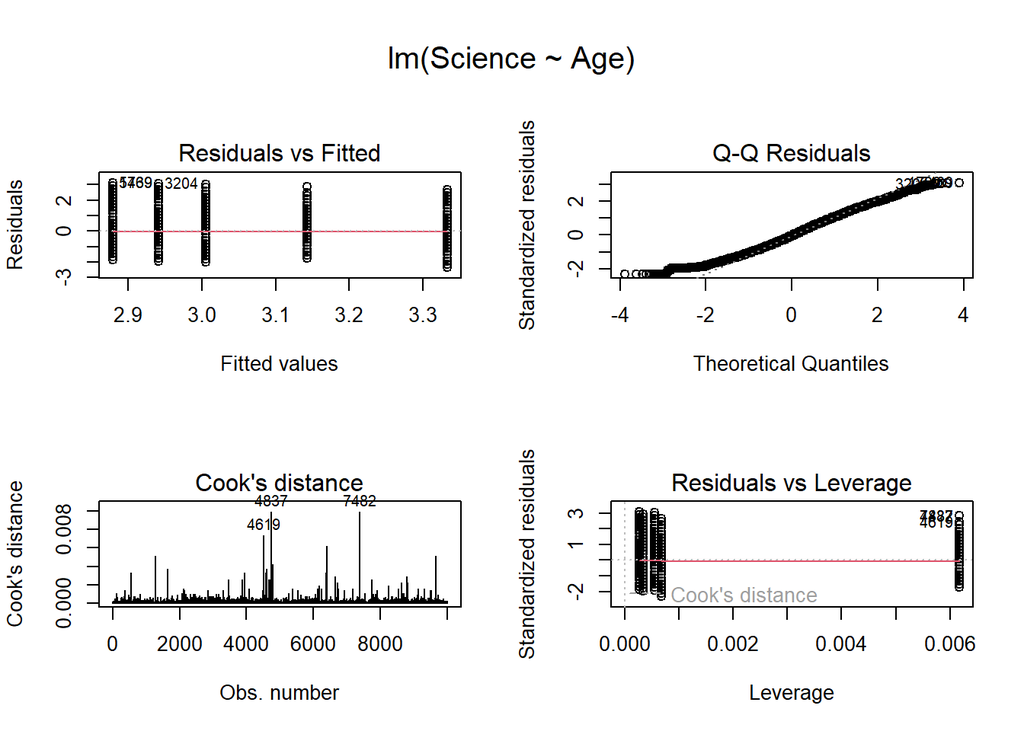

```r
par(oma =c(0,0,3,0), mfrow = c(2,2))
plot(model.NCR, which = c(1,2,4,5), add.smooth = TRUE)
```

We can see from the residuals vs fitted plot that the residuals have constant variance. From the Q-Q-plot it seems like the assumption of normally distributed residuals is met.

#### Estimate the model parameters

```r
coefs_NCR <- model.NCR$coefficients
coefs_NCR
```

```
## (Intercept)      Age(1)     Age(13)     Age(16)     Age(19)
##  3.06018171  0.08302816 -0.11909559 -0.05536652 -0.18153502
```

```r
mu_NSR <- coefs_NCR[1]
mu_1_NSR <- mu_NSR + coefs_NCR[2]
mu_13_NSR <- mu_NSR + coefs_NCR[3]
mu_16_NSR <- mu_NSR + coefs_NCR[4]
mu_19_NSR <- mu_NSR + coefs_NCR[5]

# assumption that the alpha levels sum to zero
coefs_30_NSR <- - coefs_NCR[2] - coefs_NCR[3] - coefs_NCR[4] - coefs_NCR[5]
mu_30_NSR <- mu_NSR + coefs_30_NSR

# Sigma^2 = SSE / df, from the ANOVA table
sigma2_NSR <- 10270.5 / (10000 - 5)
```

#### Test hypotheses

Test level alpha: 0.05

Hypotheses: H0: mu1 = mu2 = mu3 = mu4 = mu5 H1: At least one of the means are different. Some mui is not equal to the others.

```r
# fit anova model
car::Anova(model.NCR)
```

```
## Anova Table (Type II tests)
##
## Response: Science
##            Sum Sq   Df F value    Pr(>F)
## Age         224.8    4  54.698 < 2.2e-16 ***
## Residuals 10270.5 9995
## ---
## Signif. codes:  0 '***' 0.001 '**' 0.01 '*' 0.05 '.' 0.1 ' ' 1
```

```r
# Find the critical F alpha value

alpha = 0.05
v1_NSR = 5-1
v2_NSR = 10000 - 5

qf_NSR <- qf(1-alpha, df1 = v1, df2 = v2)


MSA_NSR <- 224.8/4
MSE_NSR <-  10270.5/9995

F_NSR <- MSA_NSR/MSE_NSR

result <- F_NSR > qf_NSR
result
```

```
## [1] TRUE
```

F_NSR >> qf_NSR, so we reject the null hypothesis. There is a significant difference in the expected liking to STEM subjects between the age groups. This can also be concluded by looking at the p-value in the ANOVA-table, which is much smaller than the test level alpha at 0.05.

#### Post-hoc test by Tukeys

```r
tukeys.NSR <- simple.glht(model.NCR, "Age", corr = c("Tukey"), level = 0.95)
print(tukeys.NSR)
```

```
##
##   Simultaneous Confidence Intervals and Tests for General Linear Hypotheses
##
## Multiple Comparisons of Means: Tukey Contrasts
##
##
## Fit: lm(formula = Science ~ Age, data = NCR.tbl)
##
## Quantile = 2.7283
## Minimum significant difference = 0.1567
## 95% confidence level
##
## Linear Hypotheses:
##          Lower   Center    Upper  Std.Err t value    P(>t)
## 1-13   0.04545  0.20212  0.35879  0.05742   3.520  0.00397 **
## 1-16  -0.01827  0.13839  0.29506  0.05742   2.410  0.11263
## 1-19   0.10789  0.26456  0.42123  0.05742   4.607 4.06e-05 ***
## 1-30  -0.34661 -0.18994 -0.03327  0.05742  -3.308  0.00838 **
## 13-16 -0.22040 -0.06373  0.09294  0.05742  -1.110  0.80148
## 13-19 -0.09423  0.06244  0.21911  0.05742   1.087  0.81318
## 13-30 -0.54873 -0.39206 -0.23540  0.05742  -6.828  < 2e-16 ***
## 16-19 -0.03050  0.12617  0.28284  0.05742   2.197  0.18077
## 16-30 -0.48500 -0.32834 -0.17167  0.05742  -5.718 1.11e-07 ***
## 19-30 -0.61117 -0.45450 -0.29783  0.05742  -7.915  < 2e-16 ***
## ---
## Signif. codes:  0 '***' 0.001 '**' 0.01 '*' 0.05 '.' 0.1 ' ' 1
## (Adjusted p values reported -- single-step method)
##
##
## WARNING: Unbalanced data may lead to poor estimates
```

We can see that there is significant difference between these age groups with a p-value < 0.05: - Group 1 and 13 - Group 1 and 19 - Group 1 and 30 - Group 13 and 30 - Group 16 and 30 - Group 19 and 30

From the confidence intervals, none of these have 0 in the interval, so they are all significantly different from each other. If 0 is included in the interval, it means that there is no significant difference between the two groups.

#### Alternative code:

```r
cld(simple.glht(model.NCR, "Age", corr = c("Tukey"), level = 0.95))
```

```
## Tukey's HSD
## Alpha: 0.05
##
##        Mean G1 G2 G3
## 30 3.333151  A
## 1  3.143210        C
## 16 3.004815     B  C
## 13 2.941086     B
## 19 2.878647     B
```

**Write a short summary of the results**

The analysis of the NSR data shows that there is a significant difference in the expected liking to STEM subjects between the age groups. The post-hoc test by Tukeys shows that there is a significant difference between many of the age groups. Age may therefore influence the liking to STEM subjects.